# MLforTimeSeriesForecasting code

## Round two: Going in with full force

```python
# Initialize periods
start_year, start_month, start_day = 2013, 2, 27
start = dt.datetime(start_year, start_month, start_day)
train_period = dt.timedelta(weeks=209)  # 4 years of training data
train_range, pred_range = get_ranges(start, train_period, pred_period, pred_times)  # keep prediction period the same
Y_total, X_total = get_data(train_range, pred_range, comed_data, lags_endo=[7 * 24])  # get the right data

# Define model
arima_orders, seasonal_orders = (1, 1, 0), (2, 0, 1, 24)  # orders used for the arima model
arima_model = sarimax.SARIMAX(Y_total[train_range], order=arima_orders, seasonal_order=seasonal_orders,
                              exog=X_total.loc[train_range, :])  # define model
```

```python
# Train model
fit_model = arima_model.fit()  # train arima model
fit_model.save("Results/arima_3", remove_data=True)
```

```
The error metrics for these predictions are the following: 4.59% (sMAPE) and 0.57 (MASE)
```

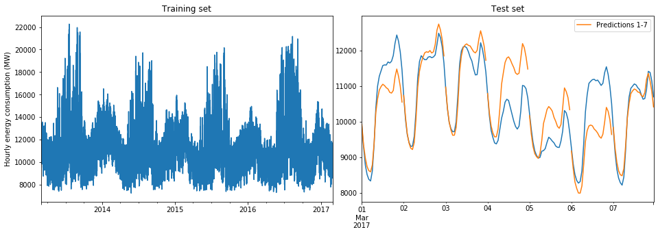

```python
# Load model and predict
saved_model = sarimax.SARIMAXResults.load("Results/arima_3")
fit_model = arima_model.filter(saved_model.params)  # add the trained parameters to the model
Y_pred = predict(Y_total, fit_model, start, train_period, pred_period, pred_times, model_type='SARIMAX',
                 orders=arima_orders, seasonal_orders=seasonal_orders, X_data=X_total)
```

```python
# Now we do the same with LSTM (we already defined Y_total and the lstm_model before)
timestep_n = 4 * 7 * 24  # predict based on values from the past month
scaler, Y_total_norm = scale_data(Y_total)  # we scale the data before we start training
```

```python
# Train model
train_data = Y_total_norm[train_range].values.reshape(-1, 1)
X_train, Y_train = get_samples(train_data, timestep_n, output_n)  # get data in the right format for keras
callback_model = ModelCheckpoint("Results/lstm_2.hdf5", monitor='val_loss', save_best_only=True)  # save the best model
callback_history = CSVLogger("Results/lstm_2.csv")  # save the training history
lstm_model.compile(Adam(), loss='mean_absolute_error')  # compile model
lstm_model.fit(X_train, Y_train, batch_size=10, epochs=50, validation_split=1/(4*12),  # validate on the last month
              callbacks=[callback_model, callback_history]) # train
```

```
The error metrics for these predictions are the following: 2.36% (sMAPE) and 0.29 (MASE)
```

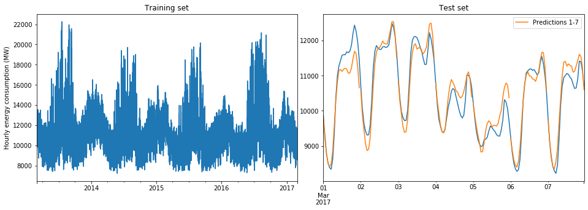

```python
# Load model and predict
fit_model = load_model("Results/lstm_2.hdf5")  # load the best model
Y_pred = predict(Y_total, fit_model, start, train_period, pred_period, pred_times, model_type='KERAS',
                 Y_data_scaled=Y_total_norm, scaler=scaler)
```

## Round three: Coach gives critical advice

Even though it is the boxer that does the fighting, input from their coach is essential. Let's see if we can further improve our models if we give them some input from outside: An exogenous variable. We obtained a dataset with the hourly weather at the Chicago Midway International Airport. Even though this is not completely representative for the weather in the whole area from which the energy consumption is taken, we assume it is a decent proxy. We will use temperature since it is expected to have the highest causational effect on energy consumption. Below is a plot of the hourly temperature on top of the hourly energy consumption.

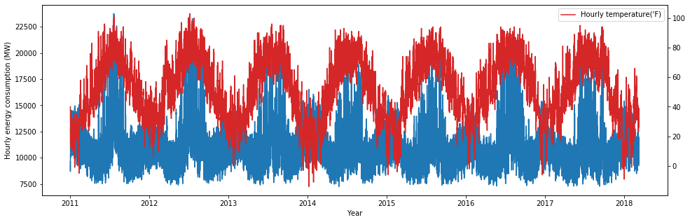

```python
# Get weather data
weather_data = pd.read_csv("Data/Chicago_MDW_weather_2010-2018.csv", dtype='unicode')  # note that weather data is in dayss
weather_data['Datetime'] = pd.to_datetime(weather_data['DATE'])  # set index to datetime values
weather_data.index = weather_data['Datetime']
weather_hourly = weather_data.loc[weather_data['REPORT_TYPE'] == 'FM-15',  # get hourly data
                                  weather_data.columns[weather_data.columns.str.startswith('Hourly')]].copy()
weather_hourly = weather_hourly.loc[weather_hourly['HourlyDryBulbTemperature'].notna()]  # remove NaNs
weather_hourly = weather_hourly.loc[weather_hourly['HourlyDryBulbTemperature'] != "*"]  # remove *s
suspect_values_loc = weather_hourly['HourlyDryBulbTemperature'].str.endswith('s') & \
                     weather_hourly['HourlyDryBulbTemperature'].notna()  # get suspect values (assume they are usable)
weather_hourly.loc[suspect_values_loc, 'HourlyDryBulbTemperature'] = \
    weather_hourly.loc[suspect_values_loc, 'HourlyDryBulbTemperature'].str[:-1]  # remove their 's'
weather_hourly['HourlyDryBulbTemperature'] = pd.to_numeric(weather_hourly['HourlyDryBulbTemperature'])  # make numeric
weather_hourly = weather_hourly.groupby(weather_hourly.index.to_period('H')).mean()  # average over hours
weather_hourly.index = weather_hourly.index.to_timestamp()  # set back to datetime object
weather_hourly = weather_hourly.sort_index()  # sort the index
temperature_hourly = weather_hourly['HourlyDryBulbTemperature']
temp_hourly = interpolate(temperature_hourly) # interpolate missing values

# Make plot including energy data
t_ax = pd.date_range(comed_data.index[0], comed_data.index[-1], freq='H')
fig, ax1 = plt.subplots()  # create figure
ax2 = ax1.twinx()  # get second axis
ax1.set_xlabel('Year')
ax1.set_ylabel('Hourly energy consumption (MW)')
ax1.plot(t_ax, comed_data[t_ax], color='C0')
ax2.plot(t_ax, temp_hourly[t_ax], color='C3')
ax2.legend(labels=['Hourly temperature(\'F)']);
```

Based on this plot we can see that energy consumption goes up when the temperature is low, but also when the temperature is high. This is to be expected in Chicago, where high temperatures make cooling necessary and low temperatures require heating. We add the two lags with the highest correlation to energy consumption to our SARIMA model. This way we deviate a bit from time series analysis and turn the model partially in a regression model, but this combination hopefully allows the model to have better predictive power. We only use the data from February to train on since that gave us better results before. We make the (not completely accurate) assumption that temperature is known for the next 24 hours. Below are the results.

```python
# We go back to the initial initialization
start_year, start_month, start_day = 2017, 2, 1  # start date
start = dt.datetime(start_year, start_month, start_day)
train_period = dt.timedelta(weeks=4)  # period we select as training data
train_range, pred_range = get_ranges(start, train_period, pred_period, pred_times)

# Get data including temperature to train on
Y_total, X_total = get_data(train_range, pred_range, comed_data, lags_endo=[7 * 24], X_data=temp_hourly,
                           lags_exo=[3, 27])  # add the two lags with the highest correlation
train_range_adjusted = (train_range + dt.timedelta(weeks=1))[:-24 * 7]  # adjust training range to remove first week
```

```python
# Do auto_arima to get best model orders
auto_arima(Y_total, exog=X_total, m=24)
```

```python
# Define model
arima_orders, seasonal_orders = (2, 0, 2), (0, 0, 2, 24)  # orders obtained from auto_arima
arima_model = sarimax.SARIMAX(Y_total[train_range_adjusted], order=arima_orders, seasonal_order=seasonal_orders,
                              exog=X_total.loc[train_range_adjusted, :])  # define model
```

```python
# Train model
fit_model = arima_model.fit()  # train arima model
fit_model.save("Results/arima_4", remove_data=True)
```

```
The error metrics for these predictions are the following: 2.94% (sMAPE) and 0.48 (MASE)
```

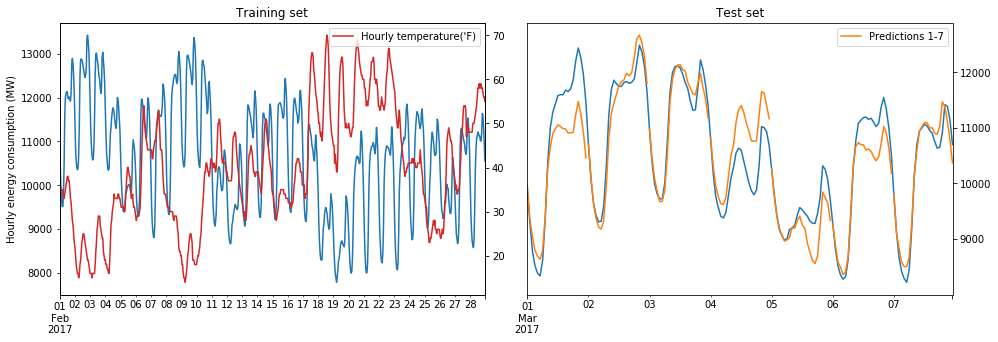

```python
# Load model and predict
saved_model = sarimax.SARIMAXResults.load("Results/arima_4")
fit_model = arima_model.filter(saved_model.params)  # add the trained parameters to the model
Y_pred = predict(Y_total, fit_model, start, train_period, pred_period, pred_times, model_type='SARIMAX',
                 orders=arima_orders, seasonal_orders=seasonal_orders, X_data=X_total, X_or=temp_hourly)
```

We see a clear improvement (0.36% sMAPE) in comparison with the earlier SARIMA model. But next to the improvement in accuracy, the structure of the SARIMA model gives us the ability to provide an answer to the question what the effect of temperature is on energy consumption. Predictive models are built on the premise that there is some relation between independent and dependent variables. Since statistics is a field of testing hypotheses around metrics that frequently relate to causality, statistical models are mostly easy to interpret and therefore yield great **explainability**. Let's look at the parameter coefficients below to see what we learn.

```python
# Print the model parameters
print(fit_model.params)
```

```
Y-168          0.905043
X-3           -6.826961
X-27           3.297200
ar.L1          0.954175
ar.L2          0.034851
ma.L1          0.372135
ma.L2          0.290757
ma.S.L24       0.355149
ma.S.L48       0.007161
sigma2      7025.931441
dtype: float64
```

Based on these parameters we can state a few things: The energy consumption of the next hour depends most heavily on the energy consumption of the week before (Y-168) and the energy consumption of the hour before (ar.L1), since both coefficients are above 0.90. A model error (difference between actual and predicted value) in one of the last two hours (ma.L1 and ma.L2) or 24 hours ago (ma.S.L24) will adjust the energy consumption of the predicted hour by about a third of its magnitude (all three coefficients between 0.29 and 0.38). For each degree Fahrenheit increase three hours before prediction (X-3), assuming everything else stays the same, the energy consumption will decrease by about 7 megawatt. This same increase for 27 hours before prediction (X-27) results in an increase of about 3 megawatt. The negative relationship makes sense since higher temperatures in February should lead to less heating. The positive relationship can be explained as being a counterbalance to the negative relationship. This combination of values indicates a negative relationship between energy consumption and temperature increase.

Let’s see how the LSTM model does. We adjust the model to have a second input and train it on 4 years of energy consumption and temperature data. Below are the results.

```python
# Initialize periods
start_year, start_month, start_day = 2013, 2, 27
start = dt.datetime(start_year, start_month, start_day)
train_period = dt.timedelta(weeks=209)  # 4 years of training data
train_range, pred_range = get_ranges(start, train_period, pred_period, pred_times)  # keep prediction period the same

# Redefine the model
input_layer = Input(shape=(None, 2))  # this time the input will take 2 features
hidden_layer = LSTM(48, return_sequences=False)(input_layer)  # add lstm layer with 48 units and only return one time unit
output_layer = Dense(output_n)(hidden_layer)  # layer with the right output
lstm_model = Model(input_layer, output_layer)  # define model input and output

# Get the right data
timestep_n = 4 * 7 * 24  # define length of input (number of time steps used to predict)
Y_total, X_total = get_data(train_range, pred_range, comed_data, X_data=temp_hourly, lags_exo=[0])  # add temperature
scaler, Y_total_norm, X_total_norm = scale_data(Y_total, X_total)  # we scale the data before we start training
```

```python
# Train and save model
train_data = Y_total_norm[train_range].values.reshape((-1, 1))
X_train_data = X_total_norm.shift(-output_n).loc[train_range, :].values  # we assume we know the temp of the next day
X_train, Y_train = get_samples(train_data, timestep_n, output_n, X_data=X_train_data)  # get data in the right format
callback_model = ModelCheckpoint("Results/lstm_3.hdf5", monitor='val_loss', save_best_only=True)  # save the best model
callback_history = CSVLogger("Results/lstm_3.csv")  # save the training history
lstm_model.compile(Adam(), loss='mean_absolute_error')  # compile model
lstm_model.fit(X_train, Y_train, batch_size=10, epochs=40, validation_split=1/(4*12),  # train the model
              callbacks=[callback_model, callback_history])
```

```
The error metrics for these predictions are the following: 1.28% (sMAPE) and 0.16 (MASE)
```

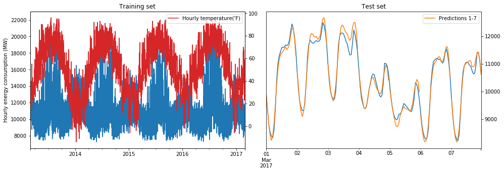

```python
# Load model and predict
fit_model = load_model("Results/lstm_3.hdf5")  # load the best model
Y_pred = predict(Y_total, fit_model, start, train_period, pred_period, pred_times, model_type='KERAS',
                 Y_data_scaled=Y_total_norm, scaler=scaler, X_data=X_total_norm.shift(-output_n),
                 X_or=temp_hourly)
```

## Who is the winner?

No knockouts today, but I am sure you had as much excitement as I did watching this match. Who did you think should win? Looking at the match statistics, or performance indicators in our case, this is not so easy. Each indicator makes one model preferable over the other, so it depends on what you value most. Below is a graph with both models and the different indicators that make the model more preferable to the other. Hopefully this helps you make a decision for your specific case!

[figure not shown]

Note that data utility ended up in the middle. Didn’t we see that the machine learning model got more accurate when using more data? It did, but that makes it a drawback to. Being able to get more value from data could also mean that the machine learning model is more dependent on data.

[figure not shown]

## Appendix

Below is a section that is not available in the blog version. It includes a few plots and code that might be interesting to people wanting to implement a case like this. If you have any question about anything said in this blog, you can always reach out to me (Noah Schutte). Thank you for reading!

[figure not shown]

```python
# Plot training history of the first lstm model
def plot_history(model_path):
    history_lstm = pd.read_csv(model_path)
    plt.plot(history_lstm['loss'], label='Train loss')
    plt.plot(history_lstm['val_loss'], label='Validation loss')
    plt.ylabel('Mean absolute error')
    plt.xlabel('Epoch number')
    plt.legend();

plot_history('Results/lstm_1.csv')
```

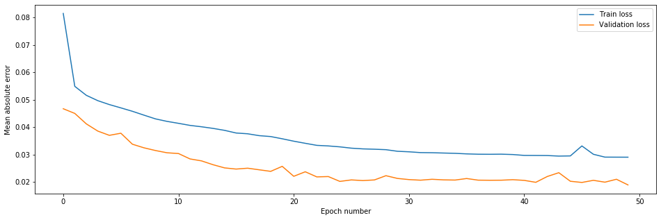

```python
# Plot training history of the first lstm model
plot_history('Results/lstm_2.csv')
```

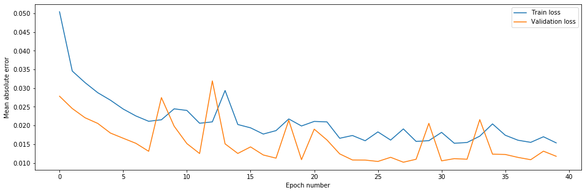

```python
# Plot training history of the first lstm model
plot_history('Results/lstm_3.csv')
```

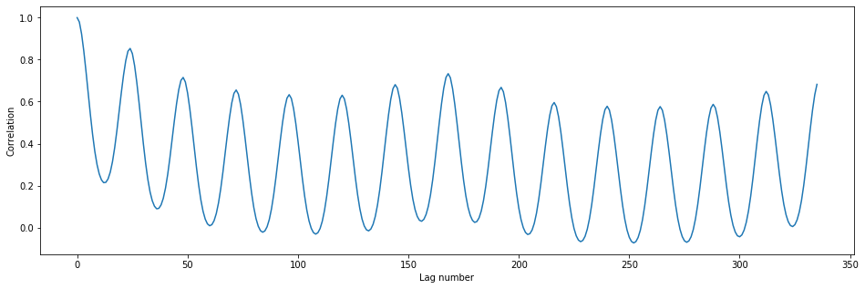

```python
# Check auto correlation of comed data
def plot_corr(data1, data2, lags):
    corrs = np.zeros(lags)
    for i in range(lags):
        corrs[i] = data1.corr(data2.shift(i))
    plt.ylabel('Correlation')
    plt.xlabel('Lag number')
    plt.plot(corrs);

plot_corr(comed_data, comed_data, 2 * 24 * 7)  # two weeks of data as lags
```

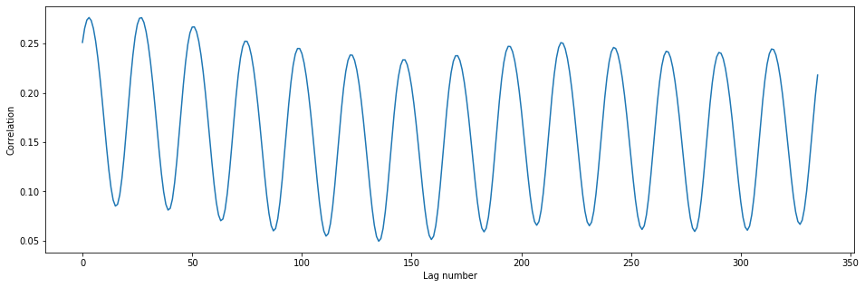

```python
# Check correlation between energy usage and temperature
plot_corr(comed_data, temp_hourly, 2 * 24 * 7)  # two weeks of data as lags
```

**References**

Energy consumption data set: https://www.kaggle.com/robikscube/hourly-energy-consumption#pjm_hourly_est.csv  
Weather data set: https://www.ncdc.noaa.gov/cdo-web/datasets/LCD/stations/WBAN:14819/detail  
Makridakas Competitions: https://en.wikipedia.org/wiki/Makridakis_Competitions  
The M4 Competition: https://www.sciencedirect.com/science/article/pii/S0169207019301128